# STA 206 Homework 5 Problem 6

Kevin Su

11/4/2021

## A

```r
setwd("C:/Users/kevin/Downloads")
property <- read.table("property.txt")
colnames(property) <- c("Y", "X1", "X2", "X3", "X4")

summary(property)
```

```
##        Y               X1               X2               X3
##  Min.   :10.50   Min.   : 0.000   Min.   : 3.000   Min.   :0.00000
##  1st Qu.:14.00   1st Qu.: 2.000   1st Qu.: 8.130   1st Qu.:0.00000
##  Median :15.00   Median : 4.000   Median :10.360   Median :0.03000
##  Mean   :15.14   Mean   : 7.864   Mean   : 9.688   Mean   :0.08099
##  3rd Qu.:16.50   3rd Qu.:15.000   3rd Qu.:11.620   3rd Qu.:0.09000
##  Max.   :19.25   Max.   :20.000   Max.   :14.620   Max.   :0.73000
##        X4
##  Min.   : 27000
##  1st Qu.: 70000
##  Median :129614
##  Mean   :160633
##  3rd Qu.:236000
##  Max.   :484290
```

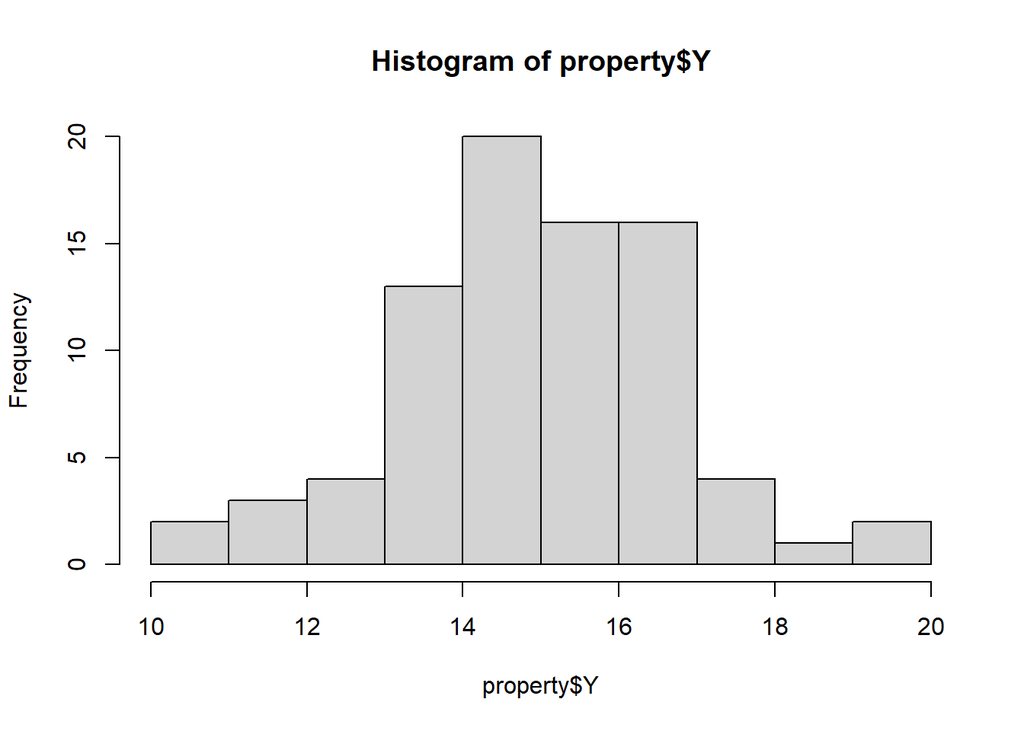

```r
hist(property$Y) #symmetric, vaguely normal
```

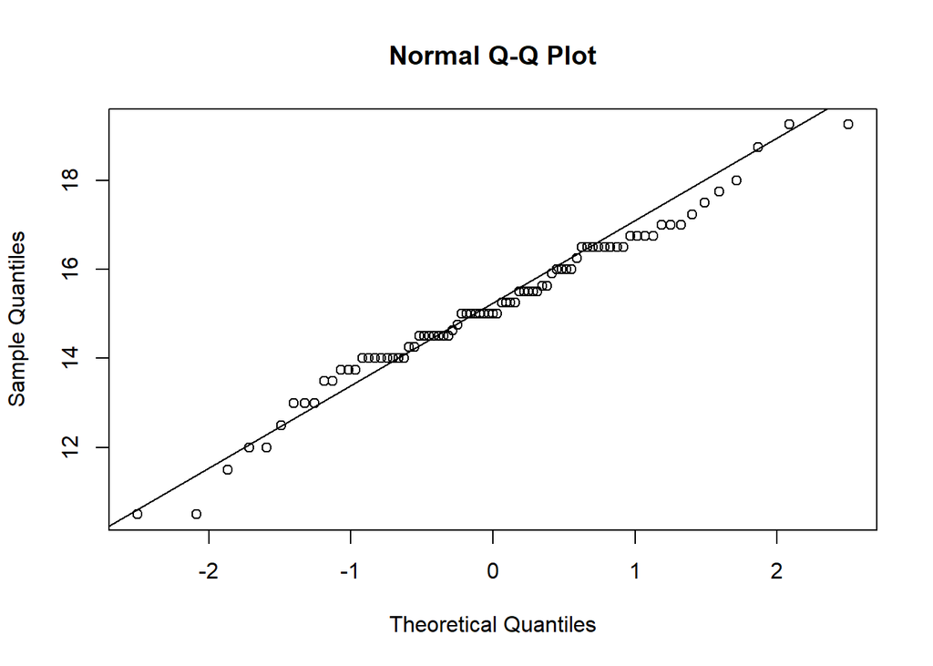

```r
qqnorm(property$Y)
qqline(property$Y)
```

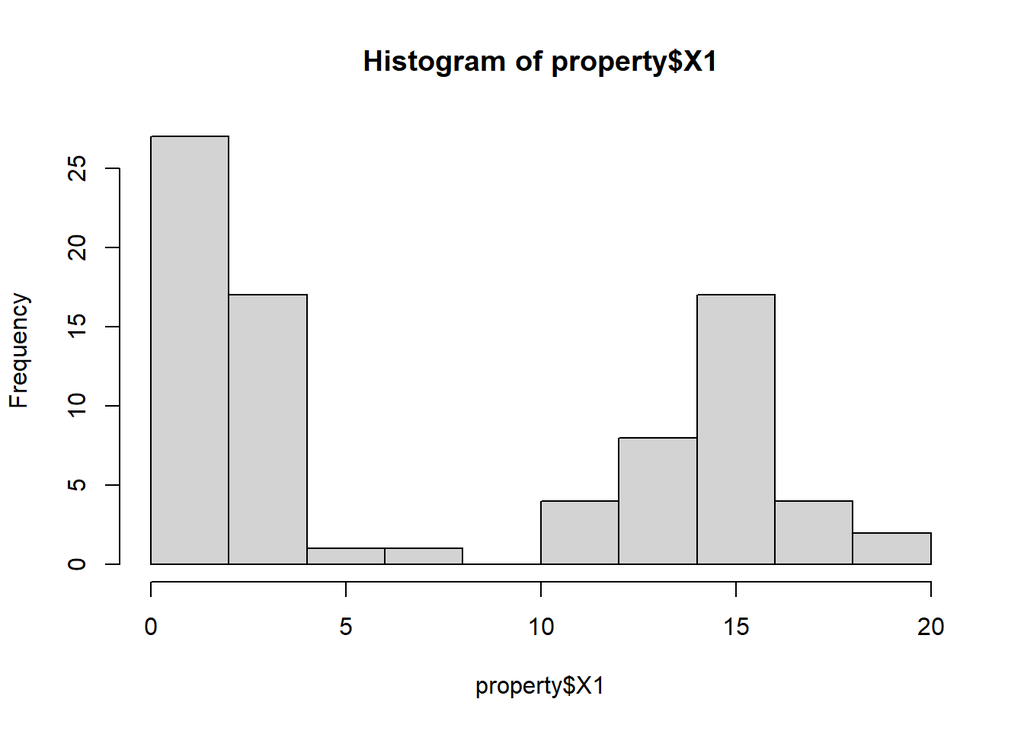

```r
hist(property$X1) #bimodal
```

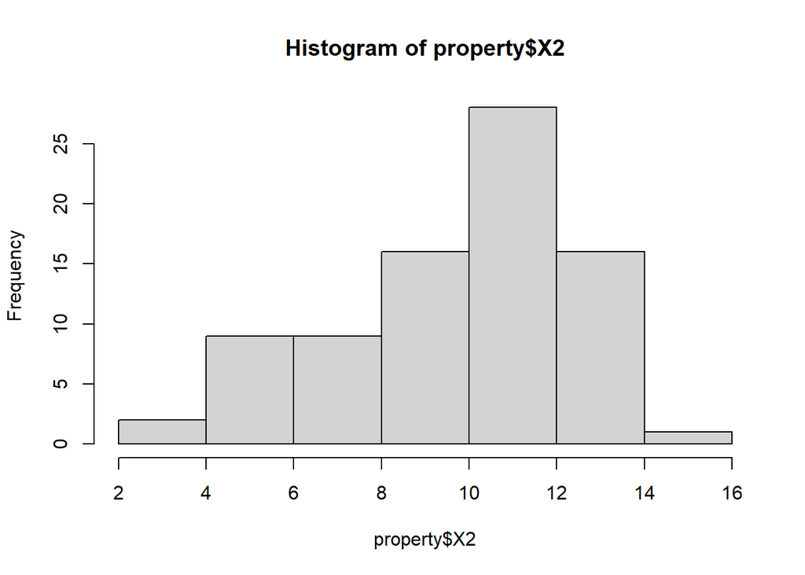

```r
hist(property$X2) #left skewed
```

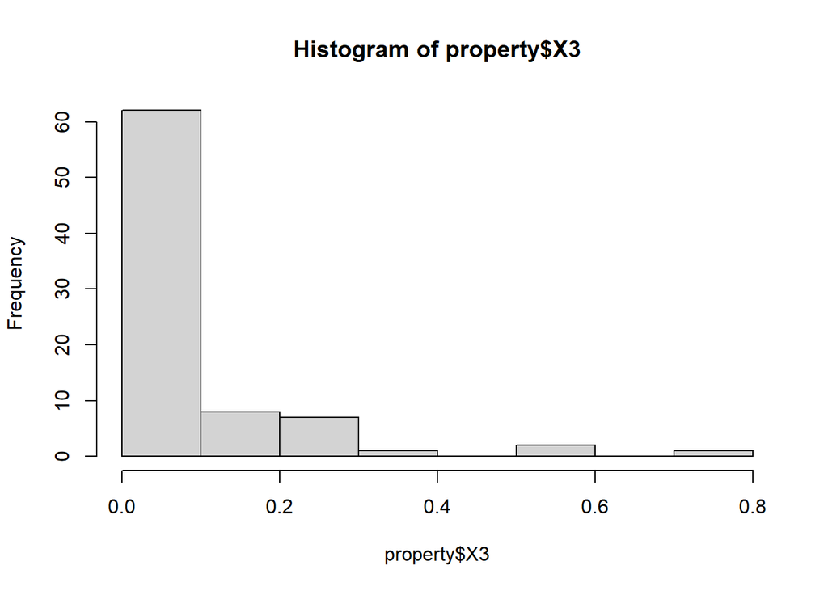

```r
hist(property$X3) #right skewed
```

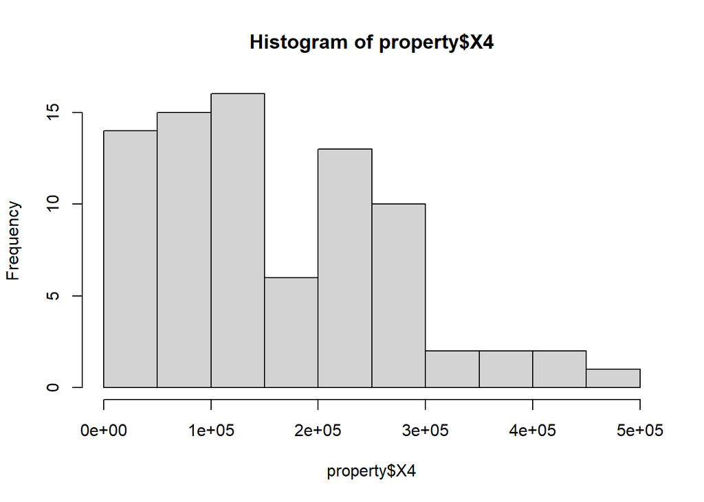

```r
hist(property$X4) #right skewed, long tail
```

From this histograms we see that Y (rental rates) is symmetric and likely normal by normal qq plot. Additionally, X1 (age) is bimodal, X2 (operating expenses) is left-skewed, X3 (vacancy rate) is right skewed, and X4 (square footage) is also right skewed with a long tail.

Y, X2, and X3 are of numeric type, X1 and X4 are of integer (int) type.

## B

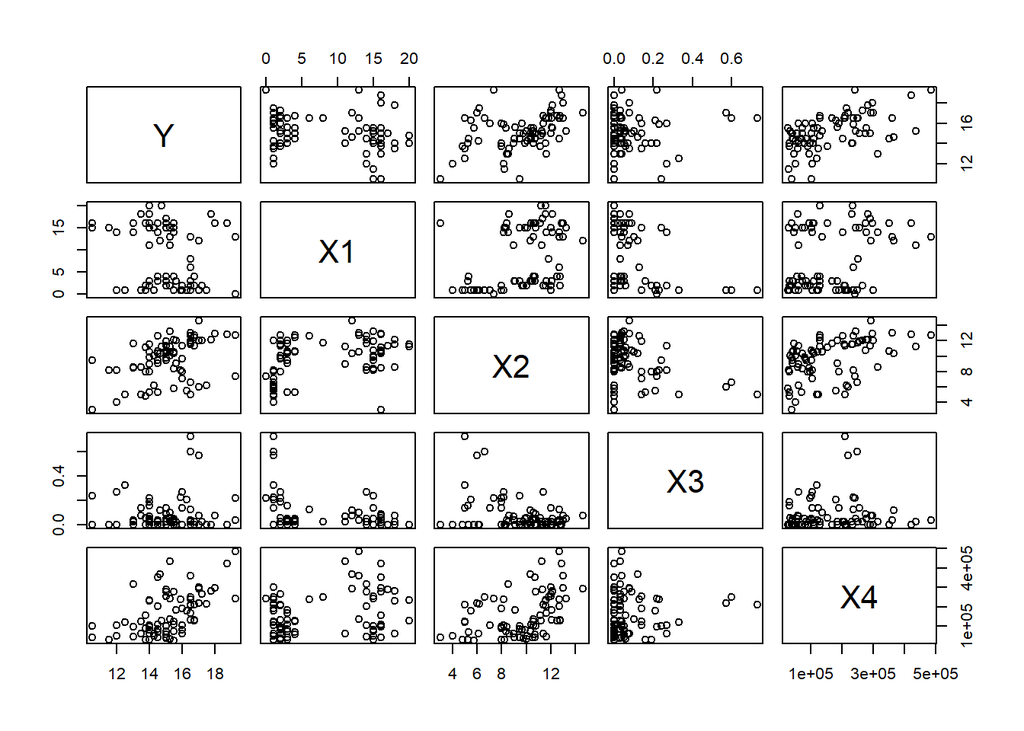

```r
pairs(~Y+X1+X2+X3+X4, data = property)
```

```r
cor(property)
```

```
##              Y         X1         X2          X3         X4
## Y   1.00000000 -0.2502846  0.4137872  0.06652647 0.53526237
## X1 -0.25028456  1.0000000  0.3888264 -0.25266347 0.28858350
## X2  0.41378716  0.3888264  1.0000000 -0.37976174 0.44069713
## X3  0.06652647 -0.2526635 -0.3797617  1.00000000 0.08061073
## X4  0.53526237  0.2885835  0.4406971  0.08061073 1.00000000
```

Y, X2, and X4 seem to be directly positively correlated with each other. X1 seems to be negatively correlated with Y. There are some very high leverage points as far in the X3 parameter that can be concerning to draw conclusions with.

## C

```r
Model1 <- lm(Y~X1+X2+X3+X4, data = property)
summary(Model1)
```

```
##
## Call:
## lm(formula = Y ~ X1 + X2 + X3 + X4, data = property)
##
## Residuals:
##     Min      1Q  Median      3Q     Max
## -3.1872 -0.5911 -0.0910  0.5579  2.9441
##
## Coefficients:
##               Estimate Std. Error t value Pr(>|t|)
## (Intercept)  1.220e+01  5.780e-01  21.110  < 2e-16 ***
## X1          -1.420e-01  2.134e-02  -6.655 3.89e-09 ***
## X2           2.820e-01  6.317e-02   4.464 2.75e-05 ***
## X3           6.193e-01  1.087e+00   0.570     0.57
## X4           7.924e-06  1.385e-06   5.722 1.98e-07 ***
## ---
## Signif. codes:  0 '***' 0.001 '**' 0.01 '*' 0.05 '.' 0.1 ' ' 1
##
## Residual standard error: 1.137 on 76 degrees of freedom
## Multiple R-squared:  0.5847, Adjusted R-squared:  0.5629
## F-statistic: 26.76 on 4 and 76 DF,  p-value: 7.272e-14
```

```r
anova(Model1)
```

```
## Analysis of Variance Table
##
## Response: Y
##           Df Sum Sq Mean Sq F value    Pr(>F)
## X1         1 14.819  14.819 11.4649  0.001125 **
## X2         1 72.802  72.802 56.3262 9.699e-11 ***
## X3         1  8.381   8.381  6.4846  0.012904 *
## X4         1 42.325  42.325 32.7464 1.976e-07 ***
## Residuals 76 98.231   1.293
## ---
## Signif. codes:  0 '***' 0.001 '**' 0.01 '*' 0.05 '.' 0.1 ' ' 1
```

The MSE is 1.293, R-squared is 0.5847, and R-squared adjusted is .5629. The Least Squares estimators are

B0 = 12.2 B1 = -.1420 B2 = 0.2820 B3 = 0.6193 B4 = 0.000007924

Y = 12.2 -.1420X1 + .2820X2 + .6193X3 + .000007924X4

## D

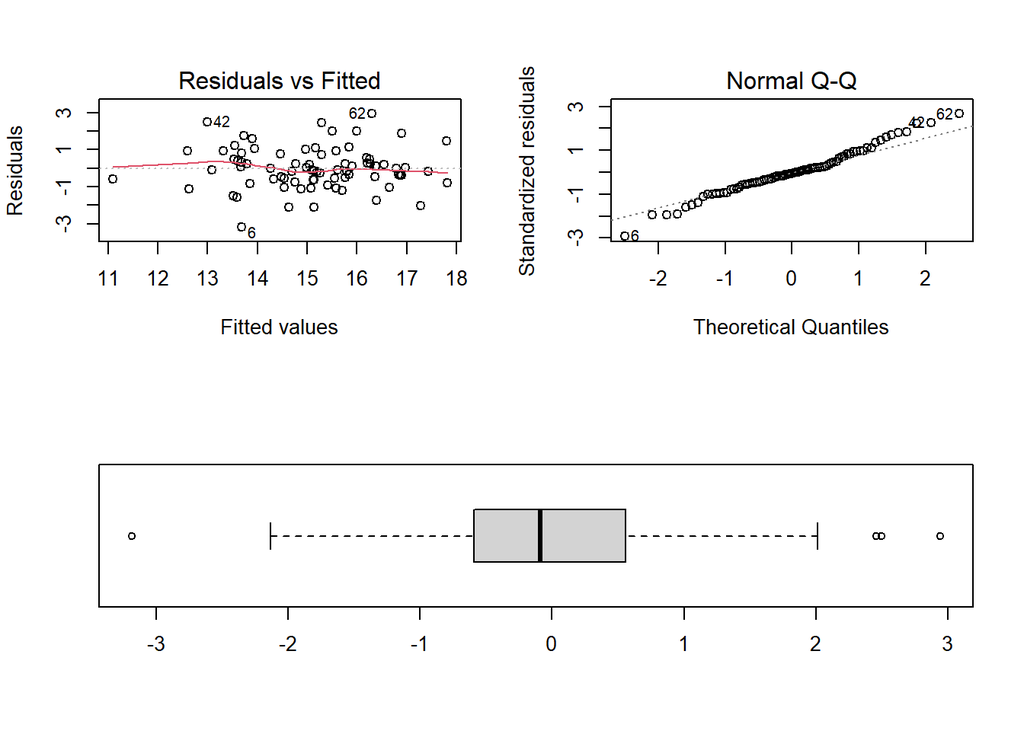

```r
layout(matrix(c(1,2,3,3), 2, 2, byrow = T))
plot(Model1, which = 1)
plot(Model1, which = 2)
boxplot(residuals(Model1), horizontal = T)
```

## E

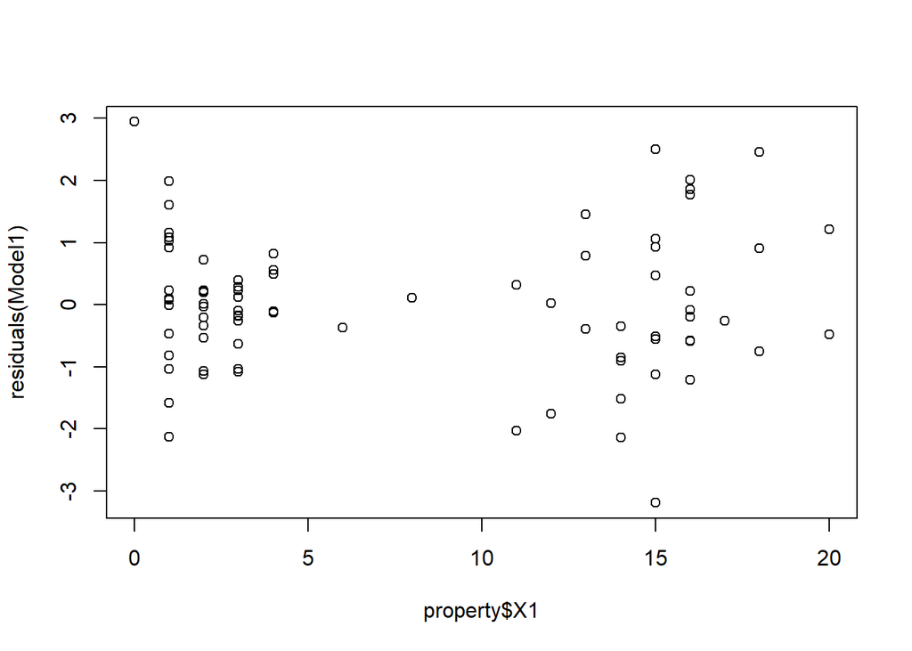

```r
plot(property$X1, residuals(Model1))
```

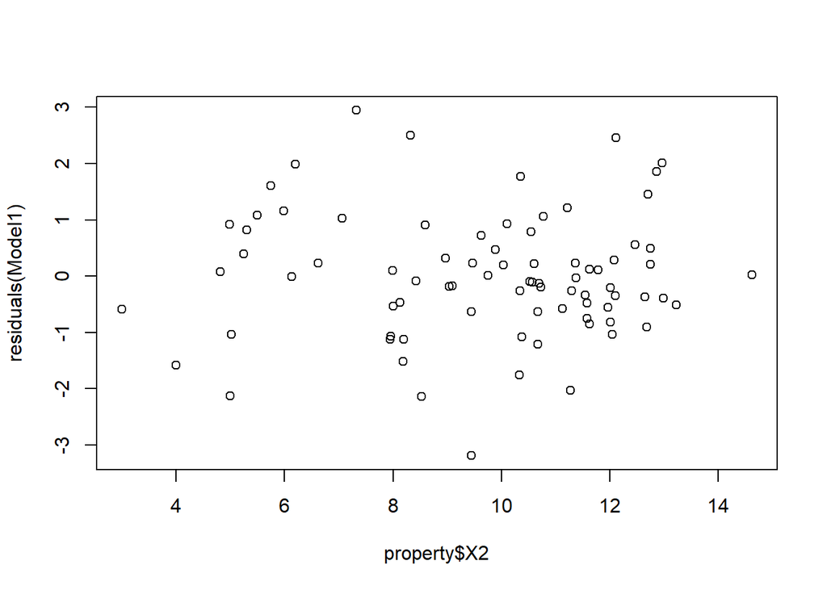

```r
plot(property$X2, residuals(Model1))
```

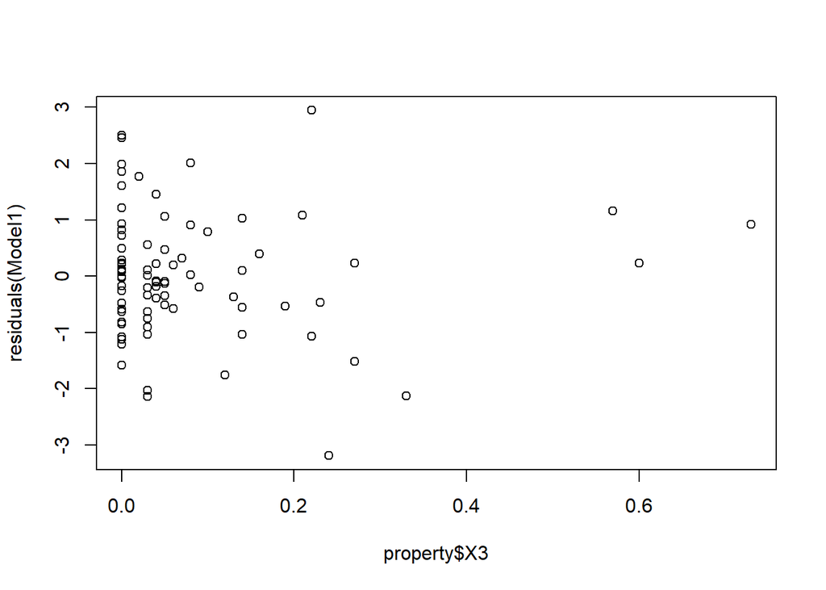

```r
plot(property$X3, residuals(Model1))
```

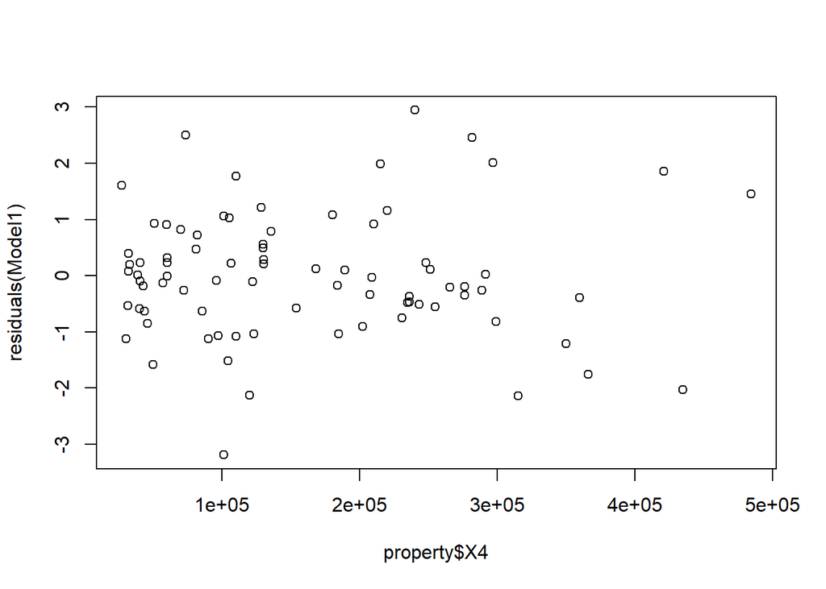

```r
plot(property$X4, residuals(Model1))
```

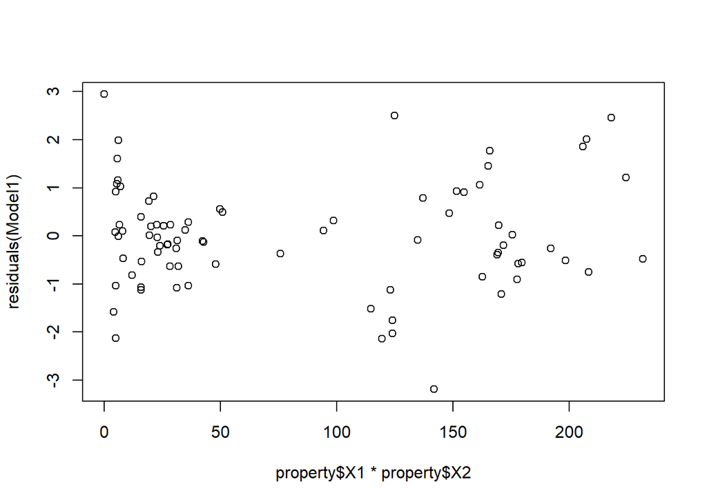

```r
plot(property$X1*property$X2, residuals(Model1))
```

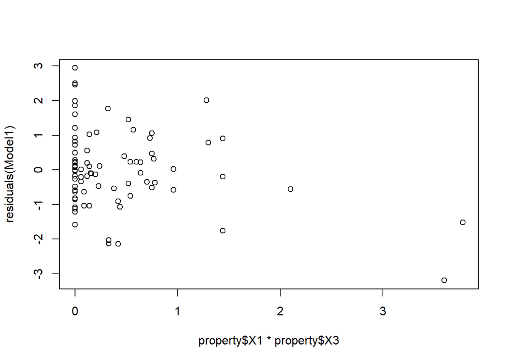

```r
plot(property$X1*property$X3, residuals(Model1))
```

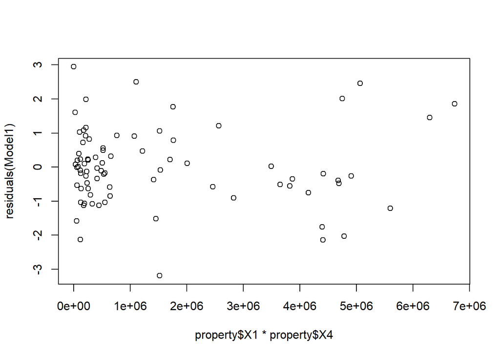

```r
plot(property$X1*property$X4, residuals(Model1))
```

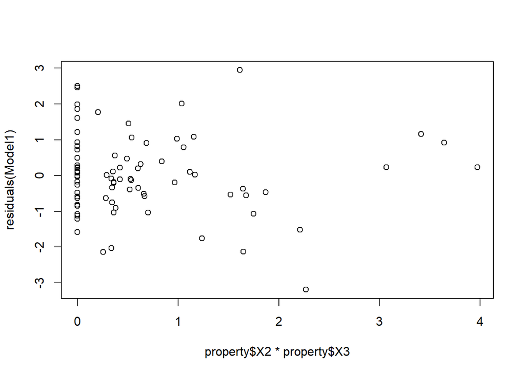

```r
plot(property$X2*property$X3, residuals(Model1))
```

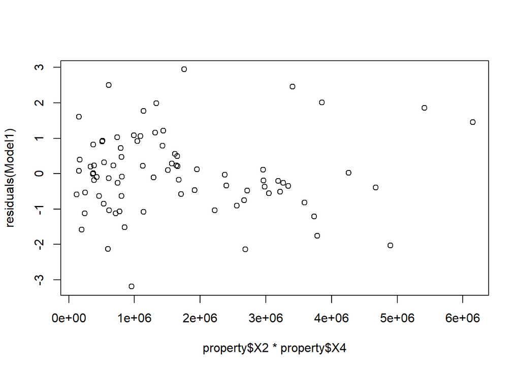

```r
plot(property$X2*property$X4, residuals(Model1))
```

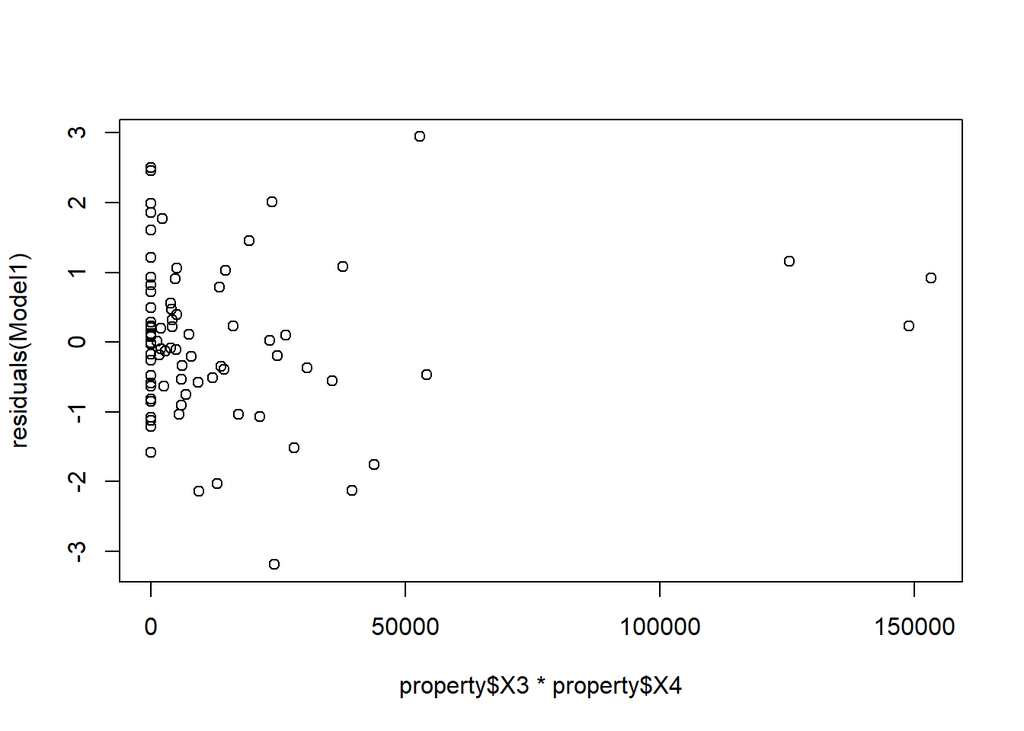

```r
plot(property$X3*property$X4, residuals(Model1))
```

There doesn’t seem to be a whole lot of effects on residuals due to two-way interaction, with the exception of maybe X1 and X3 but that may be affected by a couple high leverage outliers.

## F

```r
summary(Model1)
```

```
##
## Call:
## lm(formula = Y ~ X1 + X2 + X3 + X4, data = property)
##
## Residuals:
##     Min      1Q  Median      3Q     Max
## -3.1872 -0.5911 -0.0910  0.5579  2.9441
##
## Coefficients:
##               Estimate Std. Error t value Pr(>|t|)
## (Intercept)  1.220e+01  5.780e-01  21.110  < 2e-16 ***
## X1          -1.420e-01  2.134e-02  -6.655 3.89e-09 ***
## X2           2.820e-01  6.317e-02   4.464 2.75e-05 ***
## X3           6.193e-01  1.087e+00   0.570     0.57
## X4           7.924e-06  1.385e-06   5.722 1.98e-07 ***
## ---
## Signif. codes:  0 '***' 0.001 '**' 0.01 '*' 0.05 '.' 0.1 ' ' 1
##
## Residual standard error: 1.137 on 76 degrees of freedom
## Multiple R-squared:  0.5847, Adjusted R-squared:  0.5629
## F-statistic: 26.76 on 4 and 76 DF,  p-value: 7.272e-14
```

H0: Bi = 0 H1: Bi != 0 As P(|t|> |t.005|) or |t| > 2.642 on t distribution with df = 76, we reject null at alpha = 0.01 level for X1, X2, and X4. As P(|t|< |t.005|), we fail to reject null at alpha = 0.01 level for X3.

We conclude that X1 (age), X2 (operating expense), and X4 (total sq footage) are likely significant predictors for Y (cost of rent).

## G

```r
anova(Model1)
```

```
## Analysis of Variance Table
##
## Response: Y
##           Df Sum Sq Mean Sq F value    Pr(>F)
## X1         1 14.819  14.819 11.4649  0.001125 **
## X2         1 72.802  72.802 56.3262 9.699e-11 ***
## X3         1  8.381   8.381  6.4846  0.012904 *
## X4         1 42.325  42.325 32.7464 1.976e-07 ***
## Residuals 76 98.231   1.293
## ---
## Signif. codes:  0 '***' 0.001 '**' 0.01 '*' 0.05 '.' 0.1 ' ' 1
```

```r
summary(Model1)
```

```
##
## Call:
## lm(formula = Y ~ X1 + X2 + X3 + X4, data = property)
##
## Residuals:
##     Min      1Q  Median      3Q     Max
## -3.1872 -0.5911 -0.0910  0.5579  2.9441
##
## Coefficients:
##               Estimate Std. Error t value Pr(>|t|)
## (Intercept)  1.220e+01  5.780e-01  21.110  < 2e-16 ***
## X1          -1.420e-01  2.134e-02  -6.655 3.89e-09 ***
## X2           2.820e-01  6.317e-02   4.464 2.75e-05 ***
## X3           6.193e-01  1.087e+00   0.570     0.57
## X4           7.924e-06  1.385e-06   5.722 1.98e-07 ***
## ---
## Signif. codes:  0 '***' 0.001 '**' 0.01 '*' 0.05 '.' 0.1 ' ' 1
##
## Residual standard error: 1.137 on 76 degrees of freedom
## Multiple R-squared:  0.5847, Adjusted R-squared:  0.5629
## F-statistic: 26.76 on 4 and 76 DF,  p-value: 7.272e-14
```

SST = 236.557 SSR = 138.326 SSE = 98.231

H0: B1 = B2 = B3 = B4 = 0 H1: At least one Bi is not 0

We reject if F (.99, ndf = 4, ddf = 76) > 3.57652. As F = 26.76, we reject H0 and conclude that at least one coefficient of the predictors is not 0.

## H

```r
Model2 <- lm(Y~X1+X2+X4, data = property)
summary(Model2)
```

```
##
## Call:
## lm(formula = Y ~ X1 + X2 + X4, data = property)
##
## Residuals:
##     Min      1Q  Median      3Q     Max
## -3.0620 -0.6437 -0.1013  0.5672  2.9583
##
## Coefficients:
##               Estimate Std. Error t value Pr(>|t|)
## (Intercept)  1.237e+01  4.928e-01  25.100  < 2e-16 ***
## X1          -1.442e-01  2.092e-02  -6.891 1.33e-09 ***
## X2           2.672e-01  5.729e-02   4.663 1.29e-05 ***
## X4           8.178e-06  1.305e-06   6.265 1.97e-08 ***
## ---
## Signif. codes:  0 '***' 0.001 '**' 0.01 '*' 0.05 '.' 0.1 ' ' 1
##
## Residual standard error: 1.132 on 77 degrees of freedom
## Multiple R-squared:  0.583,  Adjusted R-squared:  0.5667
## F-statistic: 35.88 on 3 and 77 DF,  p-value: 1.295e-14
```

```r
anova(Model2)
```

```
## Analysis of Variance Table
##
## Response: Y
##           Df Sum Sq Mean Sq F value    Pr(>F)
## X1         1 14.819  14.819  11.566  0.001067 **
## X2         1 72.802  72.802  56.825 7.841e-11 ***
## X4         1 50.287  50.287  39.251 1.973e-08 ***
## Residuals 77 98.650   1.281
## ---
## Signif. codes:  0 '***' 0.001 '**' 0.01 '*' 0.05 '.' 0.1 ' ' 1
```

We fitted a model by regressing on 3 predictors as we failed to conclude that X3 was a significant predictor for Y.

B0 = 12.37058 B1 = -0.14416 B2 = 0.26717 B4 = 0.000008178

Y = 12.37058 -0.14416X1 + 0.26717X2 + 0.000008178X4

MSE = 1.281 R-squared = 0.583 R-squared adjusted = 0.5667

MSE and R-Squared is slightly lower while Adjusted R-squared is slightly higher than from Model 1 as the lower penalty for extra parameters outweighs the benefits from adding X3 as a predictor for the purpose of adjusted R-squared.

## I

```r
summary(Model2)
```

```
##
## Call:
## lm(formula = Y ~ X1 + X2 + X4, data = property)
##
## Residuals:
##     Min      1Q  Median      3Q     Max
## -3.0620 -0.6437 -0.1013  0.5672  2.9583
##
## Coefficients:
##               Estimate Std. Error t value Pr(>|t|)
## (Intercept)  1.237e+01  4.928e-01  25.100  < 2e-16 ***
## X1          -1.442e-01  2.092e-02  -6.891 1.33e-09 ***
## X2           2.672e-01  5.729e-02   4.663 1.29e-05 ***
## X4           8.178e-06  1.305e-06   6.265 1.97e-08 ***
## ---
## Signif. codes:  0 '***' 0.001 '**' 0.01 '*' 0.05 '.' 0.1 ' ' 1
##
## Residual standard error: 1.132 on 77 degrees of freedom
## Multiple R-squared:  0.583,  Adjusted R-squared:  0.5667
## F-statistic: 35.88 on 3 and 77 DF,  p-value: 1.295e-14
```

```r
confint(Model2)
```

```
##                     2.5 %        97.5 %
## (Intercept)  1.138920e+01  1.335197e+01
## X1          -1.858219e-01 -1.025074e-01
## X2           1.530784e-01  3.812557e-01
## X4           5.578873e-06  1.077755e-05
```

The Standard errors of the regression coefficients from model 2 are smaller than those in model 1. The 95% confidence intervals for model 2 are provided as output. If these intervals were constructed under Model 1, the widths would be wider than the constructed intervals from Model 2 as the standard errors of the coefficients are smaller in Model 2.

## J

```r
newobs <- data.frame(X1 = 4, X2 = 10, X3 = 0.1, X4 = 80000)
predict.lm(Model1, newobs, interval = "predict", level = 0.99)
```

```
##       fit     lwr      upr
## 1 15.1485 12.1027 18.19429
```

```r
predict.lm(Model2, newobs, interval = "predict", level = 0.99)
```

```
##        fit      lwr      upr
## 1 15.11985 12.09134 18.14836
```

The prediction intervals are provided as output. We find that the prediction interval for Model 2 is smaller than that of Model 1, due to smaller standard error.

## K

Model 2 would be preferred over Model 1 as the adjusted R-squared value is higher. X3 does not seem to be a significant predictor of Y and can likely be omitted from the model.